# A Corpus-Based Acoustic Analysis of Monophthong Vowels among Chinese Learners and Native Speakers of English - Part 2

Martin Schweinberger

2023-05-20

# Introduction

This R Notebook shows the statistical anaylsis of vowel production features of monophthongs produced by Chinese Learners and Native Speakers of English.

## Preparation

install packages

```r
# install
install.packages("tidyverse")
install.packages("here")
install.packages("viridis")
install.packages("phonR")
install.packages("vowels")
install.packages("ggridges")
install.packages("sm")
install.packages("glmmTMB")
```

load packages

```r
library(tidyverse)
library(here)
library(viridis)
library(phonR)
library(vowels)
library(ggridges)
library(sm)
options("scipen" = 100, "digits" = 12) # suppress math annotation
```

load data

```r
# load .rda data
vdf  <- base::readRDS(file = here::here("data", "vdf.rda")) %>%
  dplyr::mutate(type = stringr::str_replace_all(file, "^[A-Z]{2,}_([A-Z]{3,3})_.*", "\\1"),
                speaker = stringr::str_replace_all(file, ".*_([0-9]{3,3})_.*", "\\1")) %>%
  dplyr::mutate(tgender = stringr::str_replace_all(path, ".*F[3-7]{1,1}_([fm]{1,1})_[a-z]{2,2}$", "\\1"),
                tformants = stringr::str_replace_all(path, ".*(F[3-7]{1,1})_[fm]{1,1}_[a-z]{2,2}$", "\\1"),
                tvariety = stringr::str_remove_all(path, ".*_"))
# inspect
nrow(vdf); head(vdf)
```

```
## [1] 408695
```

```
## # A tibble: 6 × 27
##   id    Word      F1     F2 Vowel Gender   Age Duration WordClass   Frequency
##   <chr> <chr>  <dbl>  <dbl> <fct> <fct>  <dbl>    <dbl> <fct>           <dbl>
## 1 1     37     0.463  0.873 æ     male    1.83 -0.00400 grammatical     1.69
## 2 1     14    -0.375  0.117 ɛ     male    1.83 -1.10    grammatical    -0.981
## 3 1     37     0.677 -0.690 æ     male    1.83 -0.553   grammatical     1.69
## 4 1     49     1.98   0.336 ɪ     male    1.83 -1.10    grammatical     1.30
## 5 1     37     1.13  -1.08  æ     male    1.83  2.01    grammatical     1.69
## 6 1     37     1.14  -1.23  æ     male    1.83  1.65    grammatical     1.69
## # ℹ 17 more variables: NonNativeLike <fct>, Speaker <fct>, Proficiency <fct>,
## #   tmin <dbl>, tmax <dbl>, label <chr>, word <chr>, file <chr>,
## #   midpoint <dbl>, F3 <dbl>, vowel <chr>, path <chr>, type <chr>,
## #   speaker <chr>, tgender <chr>, tformants <chr>, tvariety <chr>
```

# Load Biodata

```r
bio <- read.delim(here::here("data", "biodata_icnale.txt"), header = T, sep = "\t") %>%
  dplyr::filter(stringr::str_detect(Code, "CHN|ENS")) %>%
  dplyr::mutate(type = stringr::str_replace_all(Code, "^[A-Z]{2,}_([A-Z]{3,3})_.*", "\\1"),
                speaker = stringr::str_replace_all(Code, ".*_([0-9]{3,3}).*", "\\1"),
                Sex = tolower(Sex)) %>%
  dplyr::rename(gender = Sex)
bio[bio=="N/A"]<-NA
# inspect
head(bio)
```

```
##         Code Country PTJ1..wds. PTJ2..wds. SMK1..wds. SMK2..wds. Self.Ev gender
## 1 SM_CHN_001     CHN         99        129        109        108       1      m
## 2 SM_CHN_002     CHN         52         59         43         49       1      m
## 3 SM_CHN_003     CHN         95        107         90         98       1      m
## 4 SM_CHN_004     CHN         77         81         69         90       0      f
## 5 SM_CHN_005     CHN         95        102         93        102       3      m
## 6 SM_CHN_006     CHN         89         99         98        128       1      f
##   Age Grade.Degree Yrs.of.Stay....Yrs. ENS.Type         Major..Occupation
## 1  20            1                <NA>     <NA>    Mechanical Engineering
## 2  20            2                <NA>     <NA> Nuclear Power Engineering
## 3  19            2                <NA>     <NA>    Mechanical Engineering
## 4  20            3                   1     <NA>   Information Engineering
## 5  19            2                <NA>     <NA>                   Physics
## 6  20            2                <NA>     <NA>                   Finance
##             Acad..Genre Test Score VST CEFR INTM INSM INTM.INSM INTM.INSM.1
```

[output cut: 20 more lines]

# Join data sets

Join formant and biodata

```r
fdat <- dplyr::left_join(vdf, bio, by = c("type", "speaker"))  %>%
  # filter out di- and triphthongs
  dplyr::mutate(nv = nchar(stringr::str_remove_all(label, ":"))) %>%
  dplyr::filter(nv == 1) %>%
  dplyr::filter(gender == tgender) %>%
  # remove  ref speakers with l1-var other than genam or gb
  dplyr::mutate(tvariety = dplyr::case_when(Country == "ENS_GBR" ~ "gb",
                                            Country == "ENS_CAN" ~ "us",
                                            Country == "ENS_USA" ~ "us",
                                             TRUE ~ tvariety)) %>%
  dplyr::filter(type == "CHN" | type == "ENS" & Country == "ENS_CAN" | Country == "ENS_GBR" | Country == "ENS_USA") %>%
  dplyr::filter(Age.y < 40) %>%
  dplyr::select(-Age.x) %>%
  dplyr::rename(Age = Age.y)
# inspect
head(fdat)
```

```
## # A tibble: 6 × 62
##   id    Word     F1    F2 Vowel Gender Duration WordClass Frequency
##   <chr> <chr> <dbl> <dbl> <fct> <fct>     <dbl> <fct>         <dbl>
## 1 6     <NA>   698. 1329. <NA>  <NA>         NA <NA>             NA
## 2 6     <NA>   675. 1293. <NA>  <NA>         NA <NA>             NA
## 3 6     <NA>   544. 1189. <NA>  <NA>         NA <NA>             NA
## 4 6     <NA>   590. 1313. <NA>  <NA>         NA <NA>             NA
## 5 6     <NA>   497. 1858. <NA>  <NA>         NA <NA>             NA
## 6 6     <NA>   581. 1008. <NA>  <NA>         NA <NA>             NA
## # ℹ 53 more variables: NonNativeLike <fct>, Speaker <fct>, Proficiency <fct>,
## #   tmin <dbl>, tmax <dbl>, label <chr>, word <chr>, file <chr>,
## #   midpoint <dbl>, F3 <dbl>, vowel <chr>, path <chr>, type <chr>,
## #   speaker <chr>, tgender <chr>, tformants <chr>, tvariety <chr>, Code <chr>,
## #   Country <chr>, PTJ1..wds. <int>, PTJ2..wds. <int>, SMK1..wds. <int>,
## #   SMK2..wds. <int>, Self.Ev <chr>, gender <chr>, Age <int>,
## #   Grade.Degree <chr>, Yrs.of.Stay....Yrs. <chr>, ENS.Type <chr>, …
```

overview

```r
library(janitor)
tb0 <- fdat %>%
  dplyr::ungroup() %>%
  #dplyr::filter(label == "I" | label == "i:" | label == "U" | label == "u:" ) %>%
  dplyr::group_by(type) %>%
  dplyr::mutate(speakers = length(table(speaker))) %>%
  dplyr::ungroup() %>%
  dplyr::group_by(type, label) %>%
  dplyr::summarise(speakers = speakers,
                   obs = n()) %>%
  unique() %>%
  tidyr::spread(label, obs) %>%
  dplyr::ungroup()  %>%
  adorn_totals("row")%>%
  adorn_totals("col") %>%
  dplyr::mutate(Total = Total-speakers)
# save
write.table(tb0, here::here("tables", "tb0.txt"), sep = "\t")
# inspect
tb0
```

```
##   type speakers     @     { 3:    6 A:    e    E     I    i:  O:    Q    u    U
##    CHN      148 23840  7985  5  750 75 2815 2280 20755 10175 200 1065  640 4905
##    ENS      107  5550  7100 NA  395 20  790 2810 10140  4925  80  820  815 1320
##  Total      255 29390 15085  5 1145 95 3605 5090 30895 15100 280 1885 1455 6225
##     u:     V  Total
##  10405 15125 101020
##   7910  9630  52305
##  18315 24755 153325
```

testing

```r
table(fdat$label, fdat$tvariety, fdat$type)
```

```
## , ,  = CHN
##
##
##         gb    us
##   @  23305   535
##   {   3610  4375
##   3:     5     0
##   6      0   750
##   A:    75     0
##   e   2815     0
##   E      0  2280
##   I  11385  9370
##   i:  3865  6310
##   O:   100   100
##   Q    685   380
##   u      0   640
##   U   3170  1735
##   u:  1615  8790
##   V    580 14545
##
## , ,  = ENS
##
##
##         gb    us
##   @   4905   645
##   {    465  6635
##   3:     0     0
##   6      0   395
##   A:    20     0
##   e    790     0
##   E      0  2810
##   I   1820  8320
##   i:   500  4425
##   O:     5    75
##   Q    265   555
##   u      0   815
##   U    540   780
##   u:   300  7610
##   V     65  9565
```

check proficiency

```r
fdat <- fdat %>%
  dplyr::mutate(prof = stringr::str_replace_all(file, ".*_([A-B]{1,1}[0-9]{1,1})_.*", "\\1")) %>%
  mutate(prof = ifelse(prof == file, NA, prof),
         prof = factor(prof, levels = c("A2", "B1", "B2")))
# inspect
summary(fdat$prof)
```

```
##    A2    B1    B2  NA's
##  9785 84600  6635 52305
```

# Reference data

**GenAm**

[Yang, Byunggon. 1996. A comparative study of American English and Korean vowels produced by male and female speakers. *Journal of Phonetics* 24: 245–261.](http://fonetiks.info/bgyang/db/96jp.pdf)

```r
ame <- read.delim(here::here("data/reference", "GenAm.txt"), sep = "\t", header = T) %>%
  dplyr::mutate(label = dplyr::case_when(item == "had" ~ "{",
                                         item == "heed" ~ "i:",
                                         item == "hid" ~ "I",
                                         item == "head" ~ "E",
                                         item == "hard" ~ "6",
                                         item == "whod" ~ "u:",
                                         item == "hood" ~ "U",
                                         item == "hoard" ~ "O:",
                                         item == "hud" ~ "V",
                                         item == "hod" ~ "Q",
                                         TRUE ~ "other"),
                gender = dplyr::case_when(sex == "female" ~ "f",
                                          TRUE ~ "m")) %>%
  dplyr::filter(label != "other") %>%
  dplyr::group_by(label, gender) %>%
  dplyr::summarise(target_f1 = mean(F1_Hz),
                   target_f2 = mean(F2_Hz),
                   target_f3 = mean(F3_Hz)) %>%
  dplyr::mutate(tvariety = "us")
# inspect data
head(ame)
```

```
## # A tibble: 6 × 6
## # Groups:   label [3]
##   label gender target_f1 target_f2 target_f3 tvariety
##   <chr> <chr>      <dbl>     <dbl>     <dbl> <chr>
## 1 6     f           769.     1278.     2546. us
## 2 6     m           639.     1059.     2323. us
## 3 E     f           513.     2559.     2987. us
## 4 E     m           473.     2073.     2655. us
## 5 I     f           463.     2343.     3011. us
## 6 I     m           405.     2026.     2673. us
```

**SSB**

[Deterding, David 2009. The Formants of Monophthong Vowels in Standard Southern British English Pronunciation. *Journal of the International Phonetic Association* 27, 1-2: 47-55. doi:10.1017/S0025100300005417](http://journals.cambridge.org/download.php?file=%2F7775_45AD5CD7849D3B7634A613DE6E61C294_journals__IPA_IPA27_1-2_S0025100300005417a.pdf&cover=Y&code=0639c34593b21cb18a9e7b504bdd5319)

```r
bre <- read.delim(here::here("data/reference", "SSB.txt"), sep = "\t", header = T) %>%
  dplyr::mutate(label = dplyr::case_when(item == "had" ~ "{",
                                         item == "heed" ~ "i:",
                                         item == "hid" ~ "I",
                                         item == "head" ~ "e",
                                         item == "hard" ~ "A:",
                                         item == "whod" ~ "u:",
                                         item == "hood" ~ "U",
                                         item == "hoard" ~ "O:",
                                         item == "hud" ~ "V",
                                         item == "hod" ~ "Q",
                                         TRUE ~ "other"),
                gender = dplyr::case_when(sex == "female" ~ "f",
                                          TRUE ~ "m")) %>%
  dplyr::filter(label != "other") %>%
  dplyr::group_by(label, gender) %>%
  dplyr::summarise(target_f1 = mean(F1_Hz),
                   target_f2 = mean(F2_Hz),
                   target_f3 = mean(F3_Hz)) %>%
  dplyr::mutate(tvariety = "gb")
# inspect data
head(bre)
```

```
## # A tibble: 6 × 6
## # Groups:   label [3]
##   label gender target_f1 target_f2 target_f3 tvariety
##   <chr> <chr>      <dbl>     <dbl>     <dbl> <chr>
## 1 A:    f           910.     1316.     2841. gb
## 2 A:    m           646.     1155.     2490. gb
## 3 I     f           384.     2174.     2962. gb
## 4 I     m           367.     1757.     2556  gb
## 5 O:    f           389.      888.     2796  gb
## 6 O:    m           415.      828.     2619. gb
```

Combine reference and obs data

```r
ref <- rbind(ame, bre)
fdat <- dplyr::left_join(fdat, ref) %>%
  dplyr::filter(!is.na(target_f1)) %>%
  dplyr::mutate(edist = sqrt((F1-target_f1)^2 + (F2-target_f2)^2))
# inspect
head(fdat)
```

```
## # A tibble: 6 × 67
##   id    Word     F1    F2 Vowel Gender Duration WordClass Frequency
##   <chr> <chr> <dbl> <dbl> <fct> <fct>     <dbl> <fct>         <dbl>
## 1 6     <NA>   698. 1329. <NA>  <NA>         NA <NA>             NA
## 2 6     <NA>   497. 1858. <NA>  <NA>         NA <NA>             NA
## 3 6     <NA>   581. 1008. <NA>  <NA>         NA <NA>             NA
## 4 6     <NA>   418. 1034. <NA>  <NA>         NA <NA>             NA
## 5 6     <NA>   674. 1517. <NA>  <NA>         NA <NA>             NA
## 6 6     <NA>   497   773. <NA>  <NA>         NA <NA>             NA
## # ℹ 58 more variables: NonNativeLike <fct>, Speaker <fct>, Proficiency <fct>,
## #   tmin <dbl>, tmax <dbl>, label <chr>, word <chr>, file <chr>,
## #   midpoint <dbl>, F3 <dbl>, vowel <chr>, path <chr>, type <chr>,
## #   speaker <chr>, tgender <chr>, tformants <chr>, tvariety <chr>, Code <chr>,
## #   Country <chr>, PTJ1..wds. <int>, PTJ2..wds. <int>, SMK1..wds. <int>,
## #   SMK2..wds. <int>, Self.Ev <chr>, gender <chr>, Age <int>,
## #   Grade.Degree <chr>, Yrs.of.Stay....Yrs. <chr>, ENS.Type <chr>, …
```

Determine best fit (f3:f7)

```r
fdat <- fdat %>%
  dplyr::arrange(file, tmin, tvariety, tformants) %>%
  dplyr::group_by(file, tmin) %>%
  dplyr::slice(which.min(edist))
# inspect
head(fdat)
```

```
## # A tibble: 6 × 67
## # Groups:   file, tmin [6]
##   id    Word     F1    F2 Vowel Gender Duration WordClass Frequency
##   <chr> <chr> <dbl> <dbl> <fct> <fct>     <dbl> <fct>         <dbl>
## 1 6     <NA>   698. 1329. <NA>  <NA>         NA <NA>             NA
## 2 7     <NA>   714. 1357. <NA>  <NA>         NA <NA>             NA
## 3 7     <NA>   571. 1339. <NA>  <NA>         NA <NA>             NA
## 4 7     <NA>   533. 1117. <NA>  <NA>         NA <NA>             NA
## 5 7     <NA>   509.  920. <NA>  <NA>         NA <NA>             NA
## 6 10    <NA>   497. 2031. <NA>  <NA>         NA <NA>             NA
## # ℹ 58 more variables: NonNativeLike <fct>, Speaker <fct>, Proficiency <fct>,
## #   tmin <dbl>, tmax <dbl>, label <chr>, word <chr>, file <chr>,
## #   midpoint <dbl>, F3 <dbl>, vowel <chr>, path <chr>, type <chr>,
## #   speaker <chr>, tgender <chr>, tformants <chr>, tvariety <chr>, Code <chr>,
## #   Country <chr>, PTJ1..wds. <int>, PTJ2..wds. <int>, SMK1..wds. <int>,
## #   SMK2..wds. <int>, Self.Ev <chr>, gender <chr>, Age <int>,
## #   Grade.Degree <chr>, Yrs.of.Stay....Yrs. <chr>, ENS.Type <chr>, …
```

```r
# reduce words
fdat <- fdat %>%
  #dplyr::filter(label == "U" | label == "u:" | label == "I" | label == "i:") %>%
  dplyr::filter(nchar(word) < 9,
                word != "the") %>%
  # bark normalization
  dplyr::mutate(barkF1 = normBark(F1),
                barkF2 = normBark(F2)) %>%
  # lobanov normalization
  dplyr::ungroup() %>%
  dplyr::mutate(fspeaker = paste0(type, speaker, collaspe = "")) %>%
  dplyr::group_by(type, gender, tvariety) %>%
  dplyr::mutate(lobF1 = scale(F1),
                lobF2 = scale(F2)) %>%
  # remove superfluous columns
  dplyr::select(-path, -PTJ1..wds., -PTJ2..wds., -SMK1..wds., -SMK2..wds., -Self.Ev,
                -Grade.Degree, -Acad..Genre, -VST, -CEFR, -INTM, -INSM, -INTM.INSM,
                -INTM.INSM.1, -Primary, -Secondary, -College, -Inschool, -Outschool,
                -Reading, -Writing, -NS, -Presentation, -EssayW, -nv)
# inspect
head(fdat)
```

```
## # A tibble: 6 × 47
## # Groups:   type, gender, tvariety [2]
##   id    Word     F1    F2 Vowel Gender Duration WordClass Frequency
##   <chr> <chr> <dbl> <dbl> <fct> <fct>     <dbl> <fct>         <dbl>
## 1 6     <NA>   698. 1329. <NA>  <NA>         NA <NA>             NA
## 2 7     <NA>   714. 1357. <NA>  <NA>         NA <NA>             NA
## 3 7     <NA>   571. 1339. <NA>  <NA>         NA <NA>             NA
## 4 7     <NA>   533. 1117. <NA>  <NA>         NA <NA>             NA
## 5 10    <NA>   497. 2031. <NA>  <NA>         NA <NA>             NA
## 6 6     <NA>   581. 1008. <NA>  <NA>         NA <NA>             NA
## # ℹ 38 more variables: NonNativeLike <fct>, Speaker <fct>, Proficiency <fct>,
## #   tmin <dbl>, tmax <dbl>, label <chr>, word <chr>, file <chr>,
## #   midpoint <dbl>, F3 <dbl>, vowel <chr>, type <chr>, speaker <chr>,
## #   tgender <chr>, tformants <chr>, tvariety <chr>, Code <chr>, Country <chr>,
## #   gender <chr>, Age <int>, Yrs.of.Stay....Yrs. <chr>, ENS.Type <chr>,
## #   Major..Occupation <chr>, Test <chr>, Score <chr>, Listening <chr>,
## #   Speaking <chr>, Pronunciation <chr>, prof <fct>, target_f1 <dbl>, …
```

# (Semi-)Manual cross-evaluation

check for inconsistencies

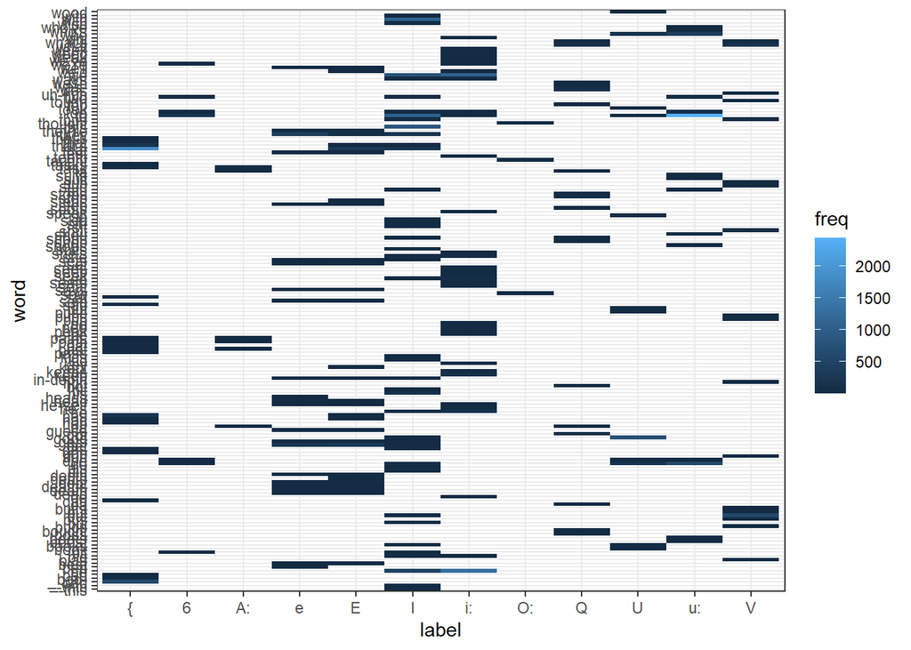

```r
fdat %>%
  dplyr::group_by(word, label) %>%
  dplyr::summarise(freq = n()) %>%
  ggplot(aes(y = word, x = label, fill = freq)) +
  geom_tile() +
  theme_bw()
```

```r
table(fdat$label, fdat$word)
```

```
##
##      –-this –-with  bad bad-\u0081 bad\u0081   be  bed best bias  big  bit book
##   {       0      0  610          1         1    0    0    0    0    0    0    0
##   6       0      0    0          0         0    0    0    0    0    0    1    0
##   A:      0      0    0          0         0    0    0    0    0    0    0    0
##   e       0      0    0          0         0    0    1   19    0    0    0    0
##   E       0      0    0          0         0    0    0   31    0    0    0    0
##   I       1      1    0          0         0  454    0    0    0   40   32    0
##   i:      0      0    0          0         0 1320    0    0    0    1    0    0
##   O:      0      0    0          0         0    0    0    0    0    0    0    0
##   Q       0      0    0          0         0    0    0    0    0    0    0    0
##   U       0      0    0          0         0    0    0    0    0    0    0   17
##   u:      0      0    0          0         0    0    0    0    0    0    0    0
##   V       0      0    0          0         0    0    0    0    1    0    0    0
##
##      books boost boots boss bought buds  bui  bus  but but\u0081 butts   da
##   {      0     0     0    0      0    0    0    0    0         0     0    0
##   6      0     0     0    0      0    0    0    0    0         0     0    0
##   A:     0     0     0    0      0    0    0    0    0         0     0    0
##   e      0     0     0    0      0    0    0    0    0         0     0    0
##   E      0     0     0    0      0    0    0    0    0         0     0    0
##   I      1     0     0    0      0    0    1    0   30         0     0    0
##   i:     0     0     0    0      0    0    0    0    0         0     0    0
##   O:     0     0     0    0      0    0    0    0    0         0     0    0
##   Q      0     0     0   12      1    0    0    0    0         0     0    1
##   U     48     0     0    0      0    0    0    0    0         0     0    0
##   u:     0     1     1    0      0    0    0    0    0         0     0    0
##   V      0     0     0    0      0    4    0    1  603         1     3    0
##
##       dad   de dead death deaths debt debts depth  did  dis   do  due  duh  gap
##   {     3    0    0     0      0    0     0     0    0    0    0    0    0    1
##   6     0    0    0     0      0    0     0     0    0    0   29    2    0    0
##   A:    0    0    0     0      0    0     0     0    0    0    0    0    0    0
##   e     0    0    3     7      3    4     0     1    0    0    0    0    0    0
##   E     0    0    3     6      3   37     2     1    0    0    0    0    0    0
##   I     0    0    0     0      0    0     0     0   17   12   76    0    0    0
##   i:    0    1    0     0      0    0     0     0    0    0    0    0    0    0
##   O:    0    0    0     0      0    0     0     0    0    0    0    0    0    0
##   Q     0    0    0     0      0    0     0     0    0    0    0    0    0    0
##   U     0    0    0     0      0    0     0     0    0    0  174    6    0    0
```

[output cut: 127 more lines]

```
##   V      0     0    0    0    0  173      9    0    0     0      0    0    0
##
##      with\u0081 wood
##   {           0    0
##   6           0    0
##   A:          0    0
##   e           0    0
##   E           0    0
##   I           1    0
##   i:          0    0
##   O:          0    0
##   Q           0    0
##   U           0    1
##   u:          0    0
##   V           0    0
```

exclude inconsistencies

```r
fdat <- fdat %>%
  dplyr::mutate(word = stringr::str_squish(word)) %>%
  dplyr::mutate(remove = dplyr::case_when(word == "--we"  ~ "remove",
                                          word == "ba"  ~ "remove",
                                          word == "da"  ~ "remove",
                                          word == "dis"  ~ "remove",
                                          word == "ha"  ~ "remove",
                                          word == "hab"  ~ "remove",
                                          word == "pat"  ~ "remove",
                                          word == "pe"  ~ "remove",
                                          word == "po"  ~ "remove",
                                          word == "shou"  ~ "remove",
                                          word == "stu"  ~ "remove",
                                          word == "sub"  ~ "remove",
                                          word == "ta"  ~ "remove",
                                          word == "ti"  ~ "remove",
                                          word == "whi"  ~ "remove",
                                          word == "duh"  ~ "remove",
                                          word == "huh"  ~ "remove",
                                          word == "bias"  ~ "remove",
                                          word == "bit" & label == "6" ~ "remove",
                                          word == "books" & label == "I" ~ "remove",
                                          word == "but" & label == "I" ~ "remove",
                                          word == "bui" & label == "I" ~ "remove",
                                          word == "de" & label == "i:" ~ "remove",
                                          word == "do" & label == "6" ~ "remove",
                                          word == "do" & label == "I" ~ "remove",
                                          word == "dust" & label == "V" ~ "remove",
                                          word == "get" & label == "I" ~ "remove",
                                          word == "gets" & label == "I" ~ "remove",
                                          word == "good" & label == "I" ~ "remove",
                                          word == "hea" ~ "remove",
                                          word == "peo" ~ "remove",
                                          word == "speak" & label == "I" ~ "remove",
                                          word == "sets" & label == "I" ~ "remove",
                                          word == "shops" & label == "I" ~ "remove",
                                          word == "stu" & label == "I" ~ "remove",
                                          word == "so" & label == "U" ~ "remove",
                                          word == "that" & label == "I" ~ "remove",
                                          word == "that's" & label == "I" ~ "remove",
                                          word == "they're" ~ "remove",
                                          word == "they" ~ "remove",
                                          word == "that\u0081's" & label == "I" ~ "remove",
                                          word == "this" & label == "O:" ~ "remove",
                                          word == "to" ~ "remove",
                                          word == "too" & label == "I" ~ "remove",
                                          word == "too" & label == "6" ~ "remove",
                                          word == "two" & label != "u:" ~ "remove",
                                          word == "ways" & label == "I" ~ "remove",
                                          word == "we're" & label == "6" ~ "remove",
                                          word == "we're" & label == "6" ~ "remove",
                                          word == "gas" & label == "I" ~ "remove",
                                          vowel == "ɐ" ~ "remove",
                                          stringr::str_detect(word, "\\W") ~ "remove",
                                          TRUE ~ "keep")) %>%
  dplyr::filter(remove != "remove")
# inspect
table(fdat$label, fdat$word)[1:6,]
```

```
##
##       bad   be  bed best  big  bit book books boost boots boss bought buds  bus
##   {   610    0    0    0    0    0    0     0     0     0    0      0    0    0
##   A:    0    0    0    0    0    0    0     0     0     0    0      0    0    0
##   e     0    0    1   19    0    0    0     0     0     0    0      0    0    0
##   E     0    0    0   31    0    0    0     0     0     0    0      0    0    0
##   I     0  454    0    0   40   32    0     0     0     0    0      0    0    0
##   i:    0 1320    0    0    1    0    0     0     0     0    0      0    0    0
##
##       but butts  dad dead death deaths debt debts depth  did   do  due  gap
##   {     0     0    3    0     0      0    0     0     0    0    0    0    1
##   A:    0     0    0    0     0      0    0     0     0    0    0    0    0
##   e     0     0    0    3     7      3    4     0     1    0    0    0    0
##   E     0     0    0    3     6      3   37     2     1    0    0    0    0
##   I     0     0    0    0     0      0    0     0     0   17    0    0    0
##   i:    0     0    0    0     0      0    0     0     0    0    0    0    0
##
##       gas  get gets good  got guess  had  has   he head heads  his  hit  hot
##   {     9    0    0    0    0     0   43  199    0    0     0    0    0    0
##   A:    0    0    0    0    0     0    0    0    0    0     0    0    0    0
##   e     0  219    9    0    0     5    0    0    0    3     2    0    0    0
##   E     0  290   11    0    0    27   13   17    0    2     0    0    0    0
##   I     0    0    0    0    0     0    0    0   64    0     0  134    2    0
##   i:    0    0    0    0    0     0    0    0  133    0     0    0    0    0
##
##      keep keeps kept  key  kid kids pass past path paths peak  pub pubs push
##   {     0     0    0    0    0    0    2    6    2     1    0    0    0    0
##   A:    0     0    0    0    0    0    0    6    2     1    0    0    0    0
##   e     0     0    0    0    0    0    0    0    0     0    0    0    0    0
##   E     0     0    2    0    0    0    0    0    0     0    0    0    0    0
##   I     0     0    0    0    4   17    0    0    0     0    0    0    0    0
##   i:   72     2    0    2    0    0    0    0    0     0    2    0    0    0
##
##       put  sad said  sat  saw says seat seats  see seek seep sees  set sets
##   {     0    3    0    2    0    0    0     0    0    0    0    0    0    0
##   A:    0    0    0    0    0    0    0     0    0    0    0    0    0    0
##   e     0    0   20    0    0    1    0     0    0    0    0    0    5    3
##   E     0    0   51    0    0    8    0     0    0    0    0    0    9    2
##   I     0    0    0    0    0    0    0     0    1    0    0    0    0    0
##   i:    0    0    0    0    0    0    2     4   85    2    1    1    0    0
```

[output cut: 17 more lines]

```
##       too took  top tough  two  was wash ways   we weak weed week what  who
##   {     0    0    0     0    0    0    0    0    0    0    0    0    0    0
##   A:    0    0    0     0    0    0    0    0    0    0    0    0    0    0
##   e     0    0    0     0    0    0    0    0    0    0    0    0    0    0
##   E     0    0    0     0    0    0    0    0    0    0    0    0    0    0
##   I     0    0    0     0    0    0    0    0  825    0    0    0    0    0
##   i:    2    0    0     0    0    0    0    1 1076   17    2    8    0    0
##
##      wish with wood
##   {     0    0    0
##   A:    0    0    0
##   e     0    0    0
##   E     0    0    0
##   I    13 1077    0
##   i:    0    0    0
```

```r
table(fdat$label, fdat$word)[7:11,]
```

```
##
##      bad  be bed best big bit book books boost boots boss bought buds bus but
##   O:   0   0   0    0   0   0    0     0     0     0    0      0    0   0   0
##   Q    0   0   0    0   0   0    0     0     0     0   12      1    0   0   0
##   U    0   0   0    0   0   0   17    48     0     0    0      0    0   0   0
##   u:   0   0   0    0   0   0    0     0     1     1    0      0    0   0   0
##   V    0   0   0    0   0   0    0     0     0     0    0      0    4   1 603
##
##      butts dad dead death deaths debt debts depth did  do due gap gas get gets
##   O:     0   0    0     0      0    0     0     0   0   0   0   0   0   0    0
##   Q      0   0    0     0      0    0     0     0   0   0   0   0   0   0    0
##   U      0   0    0     0      0    0     0     0   0 174   6   0   0   0    0
##   u:     0   0    0     0      0    0     0     0   0 591   8   0   0   0    0
##   V      3   0    0     0      0    0     0     0   0   0   0   0   0   0    0
##
##      good got guess had has  he head heads his hit hot keep keeps kept key kid
##   O:    0   0     0   0   0   0    0     0   0   0   0    0     0    0   0   0
##   Q     0  53     0   0   0   0    0     0   0   0   1    0     0    0   0   0
##   U   735   0     0   0   0   0    0     0   0   0   0    0     0    0   0   0
##   u:    0   0     0   0   0   0    0     0   0   0   0    0     0    0   0   0
##   V     0   0     0   0   0   0    0     0   0   0   0    0     0    0   0   0
##
##      kids pass past path paths peak pub pubs push put sad said sat saw says
##   O:    0    0    0    0     0    0   0    0    0   0   0    0   0   4    0
##   Q     0    0    0    0     0    0   0    0    0   0   0    0   0   0    0
##   U     0    0    0    0     0    0   0    0    3  48   0    0   0   0    0
##   u:    0    0    0    0     0    0   0    0    0   0   0    0   0   0    0
##   V     0    0    0    0     0    0   5    3    0   0   0    0   0   0    0
##
##      seat seats see seek seep sees set sets she shits shoes shop shops shut sit
##   O:    0     0   0    0    0    0   0    0   0     0     0    0     0    0   0
##   Q     0     0   0    0    0    0   0    0   0     0     0    6     2    0   0
##   U     0     0   0    0    0    0   0    0   0     0     0    0     0    0   0
##   u:    0     0   0    0    0    0   0    0   0     0     2    0     0    0   0
##   V     0     0   0    0    0    0   0    0   0     0     0    0     0    3   0
##
##      skip speak spots step steps stop stops stud suit suits task tasks taught
##   O:    0     0     0    0     0    0     0    0    0     0    0     0     33
##   Q     0     0     1    0     0   61     2    0    0     0    0     0      0
##   U     0     0     0    0     0    0     0    0    0     0    0     0      0
##   u:    0     0     0    0     0    0     0    0    3     1    0     0      0
##   V     0     0     0    0     0    0     0    3    0     0    0     0      0
##
##      teeth test that this thought thus too took top tough two was wash ways  we
##   O:     0    0    0    0      17    0   0    0   0     0   0   0    0    0   0
##   Q      0    0    0    0       0    0   0    0   6     0   0 107    2    0   0
##   U      0    0    0    0       0    0   0   10   0     0   0   0    0    0   0
##   u:     0    0    0    0       0    0  99    0   0     0  56   0    0    0   0
##   V      0    0    0    0       0    8   0    0   0    11   0   0    0    0   0
##
##      weak weed week what who wish with wood
##   O:    0    0    0    0   0    0    0    0
##   Q     0    0    0  106   0    0    0    0
##   U     0    0    0    0 142    0    0    1
##   u:    0    0    0    0 382    0    0    0
##   V     0    0    0  173   0    0    0    0
```

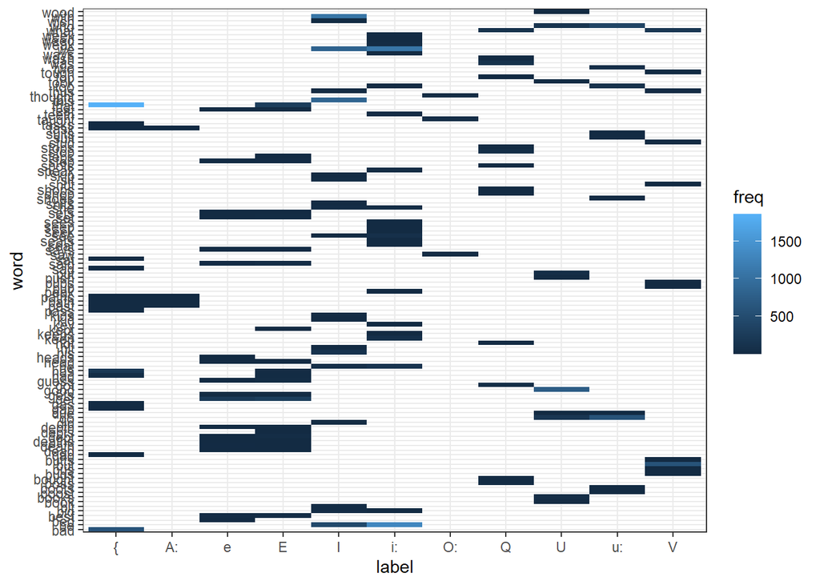

```r
fdat %>%
  dplyr::group_by(word, label) %>%
  dplyr::summarise(freq = n()) %>%
  ggplot(aes(y = word, x = label, fill = freq)) +
  geom_tile() +
  theme_bw()
```

## Check durations

```r
fdat <- fdat %>%
  # duration
  dplyr::mutate(duration = tmax - tmin)
# inspect
head(fdat)
```

```
## # A tibble: 6 × 49
## # Groups:   type, gender, tvariety [2]
##   id    Word     F1    F2 Vowel Gender Duration WordClass Frequency
##   <chr> <chr> <dbl> <dbl> <fct> <fct>     <dbl> <fct>         <dbl>
## 1 6     <NA>   698. 1329. <NA>  <NA>         NA <NA>             NA
## 2 7     <NA>   714. 1357. <NA>  <NA>         NA <NA>             NA
## 3 10    <NA>   497. 2031. <NA>  <NA>         NA <NA>             NA
## 4 6     <NA>   581. 1008. <NA>  <NA>         NA <NA>             NA
## 5 7     <NA>   638. 1169. <NA>  <NA>         NA <NA>             NA
## 6 10    <NA>   418. 1328. <NA>  <NA>         NA <NA>             NA
## # ℹ 40 more variables: NonNativeLike <fct>, Speaker <fct>, Proficiency <fct>,
## #   tmin <dbl>, tmax <dbl>, label <chr>, word <chr>, file <chr>,
## #   midpoint <dbl>, F3 <dbl>, vowel <chr>, type <chr>, speaker <chr>,
## #   tgender <chr>, tformants <chr>, tvariety <chr>, Code <chr>, Country <chr>,
## #   gender <chr>, Age <int>, Yrs.of.Stay....Yrs. <chr>, ENS.Type <chr>,
## #   Major..Occupation <chr>, Test <chr>, Score <chr>, Listening <chr>,
## #   Speaking <chr>, Pronunciation <chr>, prof <fct>, target_f1 <dbl>, …
```

plot durations

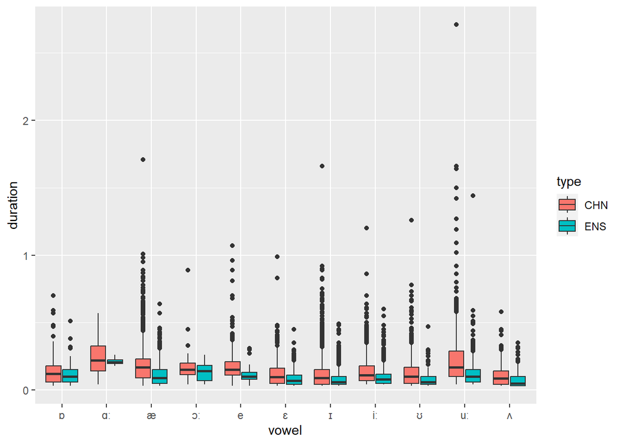

```r
fdat %>%
  ggplot(aes(x = vowel, y = duration, fill = type)) +
  geom_boxplot()
```

```r
max_durs <- fdat %>%
  dplyr::group_by(type, tvariety, vowel) %>%
  dplyr::summarise(du_min = min(duration),
                   du_max = max(duration),
                   du_ave = mean(duration),
                   du_med = median(duration),
                   du_sd = sd(duration),
                   du_2sd = sd(duration)*1.645) %>%
  dplyr::mutate(cutoff_duration = du_ave + du_2sd) %>%
  dplyr::select(type, tvariety, vowel, cutoff_duration)
# inspect
head(max_durs)
```

```
## # A tibble: 6 × 4
## # Groups:   type, tvariety [1]
##   type  tvariety vowel cutoff_duration
##   <chr> <chr>    <chr>           <dbl>
## 1 CHN   gb       e               0.422
## 2 CHN   gb       iː              0.370
## 3 CHN   gb       uː              0.767
## 4 CHN   gb       æ               0.483
## 5 CHN   gb       ɑː              0.503
## 6 CHN   gb       ɒ               0.341
```

remove duration outliers

```r
fdat <- dplyr::left_join(fdat, max_durs) %>%
  dplyr::filter(duration <= cutoff_duration,
                ifelse(label != "A:", duration <= 0.4, duration <= 0.75))
# inspect
head(fdat); nrow(fdat)
```

```
## # A tibble: 6 × 50
## # Groups:   type, gender, tvariety [2]
##   id    Word     F1    F2 Vowel Gender Duration WordClass Frequency
##   <chr> <chr> <dbl> <dbl> <fct> <fct>     <dbl> <fct>         <dbl>
## 1 6     <NA>   698. 1329. <NA>  <NA>         NA <NA>             NA
## 2 7     <NA>   714. 1357. <NA>  <NA>         NA <NA>             NA
## 3 10    <NA>   497. 2031. <NA>  <NA>         NA <NA>             NA
## 4 6     <NA>   581. 1008. <NA>  <NA>         NA <NA>             NA
## 5 7     <NA>   638. 1169. <NA>  <NA>         NA <NA>             NA
## 6 10    <NA>   418. 1328. <NA>  <NA>         NA <NA>             NA
## # ℹ 41 more variables: NonNativeLike <fct>, Speaker <fct>, Proficiency <fct>,
## #   tmin <dbl>, tmax <dbl>, label <chr>, word <chr>, file <chr>,
## #   midpoint <dbl>, F3 <dbl>, vowel <chr>, type <chr>, speaker <chr>,
## #   tgender <chr>, tformants <chr>, tvariety <chr>, Code <chr>, Country <chr>,
## #   gender <chr>, Age <int>, Yrs.of.Stay....Yrs. <chr>, ENS.Type <chr>,
## #   Major..Occupation <chr>, Test <chr>, Score <chr>, Listening <chr>,
## #   Speaking <chr>, Pronunciation <chr>, prof <fct>, target_f1 <dbl>, …
```

```
## [1] 12902
```

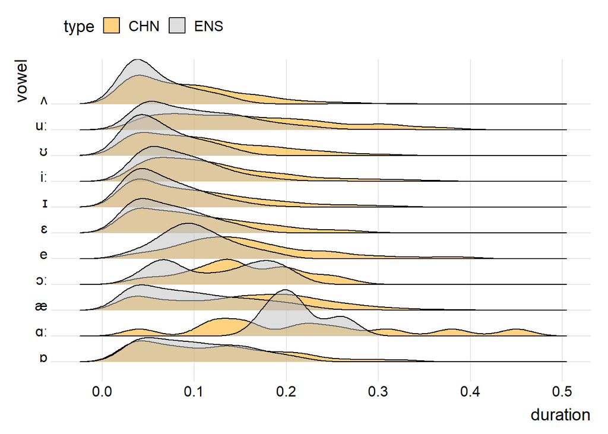

```r
dur_IiUu <-  fdat %>%
  #dplyr::filter(label == "i:" | label == "I" | label == "u:" | label == "U") %>%
  ggplot(aes(y = vowel, x = duration, fill = type)) +
  geom_density_ridges(alpha = .5) +
  theme_ridges() +
  theme(legend.position = "top") +
  scale_fill_manual(values = c("orange", "gray"))
ggsave(here::here("images", "dur_IiUu.png"), height = 3,  width = 5, dpi = 320)
dur_IiUu
```

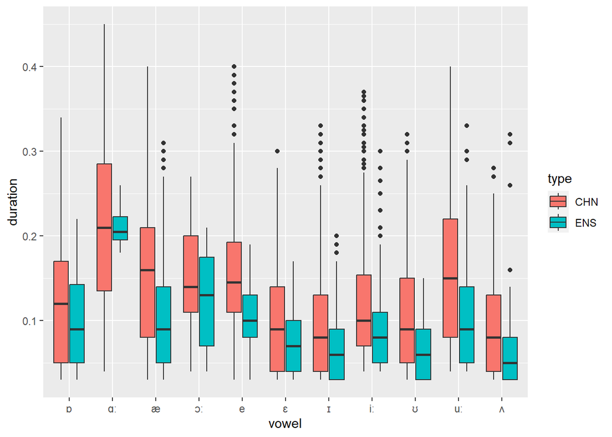

```r
fdat %>%
  ggplot(aes(x = vowel, y = duration, fill = type)) +
  geom_boxplot()
```

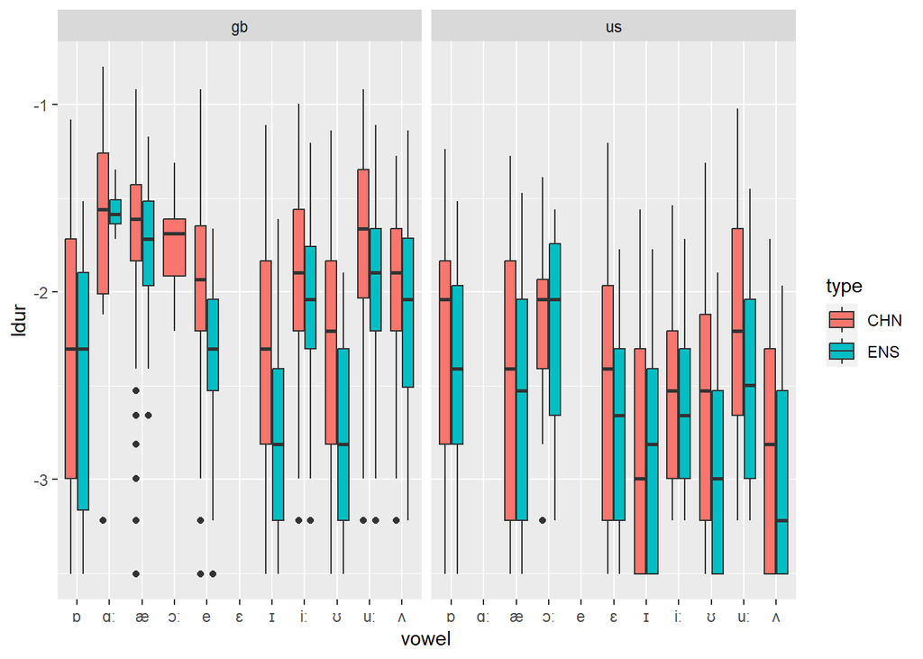

```r
fdat %>%
  dplyr::group_by(type, tvariety, vowel) %>%
  dplyr::mutate(ldur = log(duration)) %>%
  ggplot(aes(x = vowel, y = ldur, fill = type)) +
  geom_boxplot() +
  facet_grid(~tvariety)
```

# Remove outliers

```r
nrow(fdat)
```

```
## [1] 12902
```

```r
fdat <- fdat %>%
  dplyr::group_by(type, tvariety, label) %>%
  dplyr::mutate(densF1 = sm.density(barkF1,eval.points=barkF1)$estimate,
                densF2 = sm.density(barkF2,eval.points=barkF2)$estimate,
                qnt1F1 = quantile(densF1, .5, na.rm = T),
                qnt1F2 = quantile(densF2, .5, na.rm = T))
```

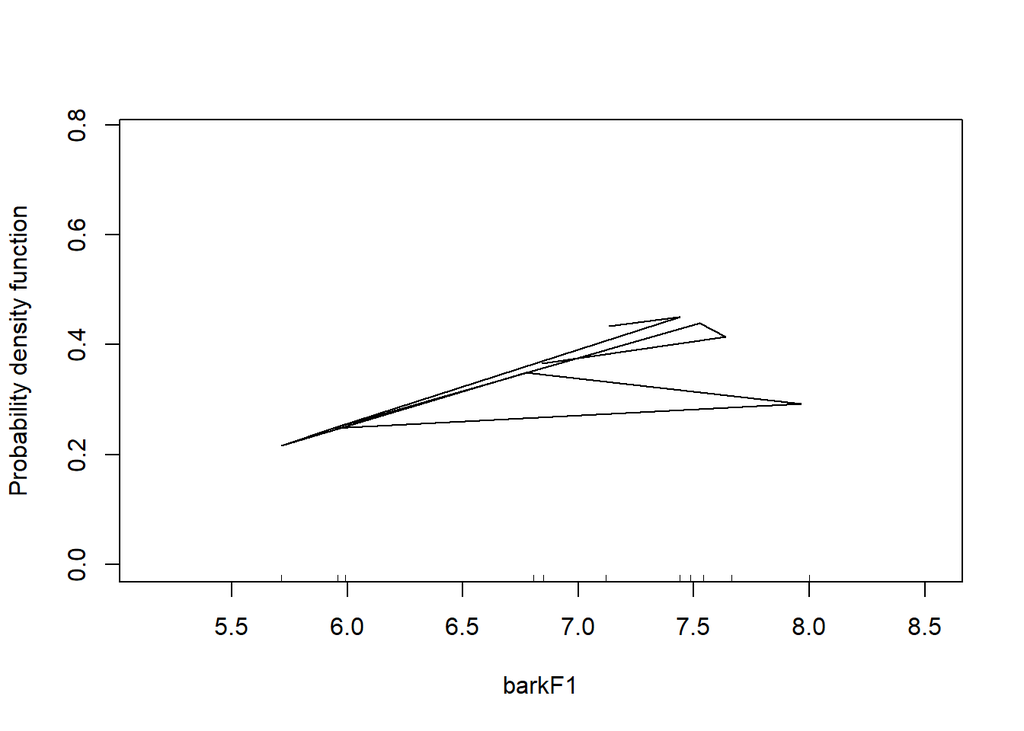

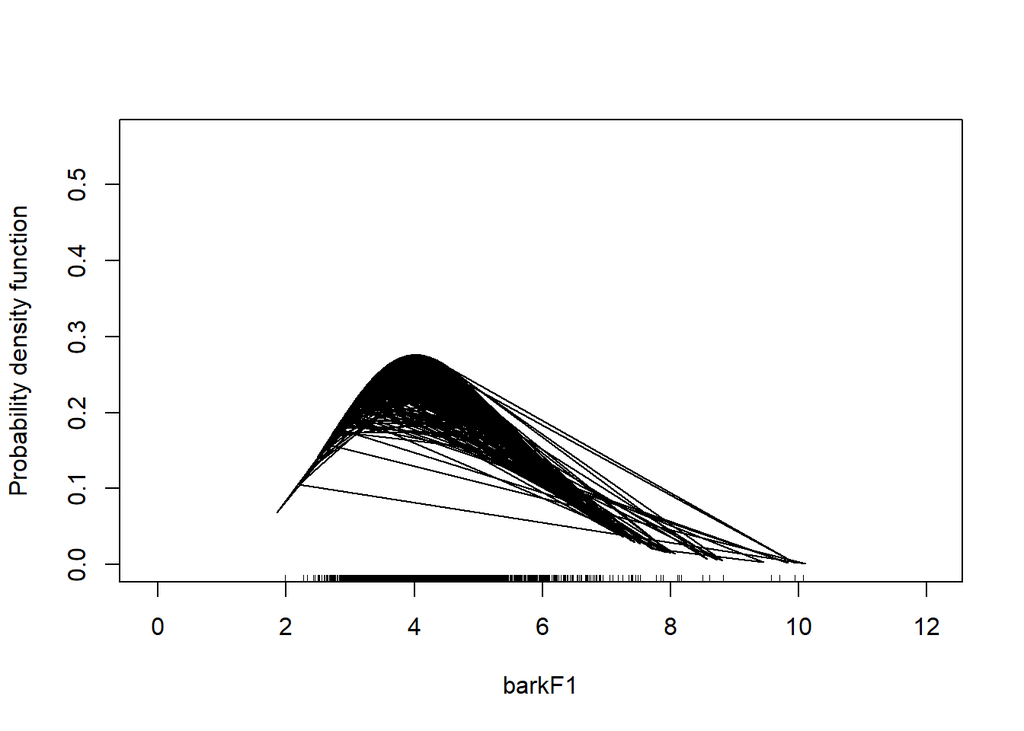

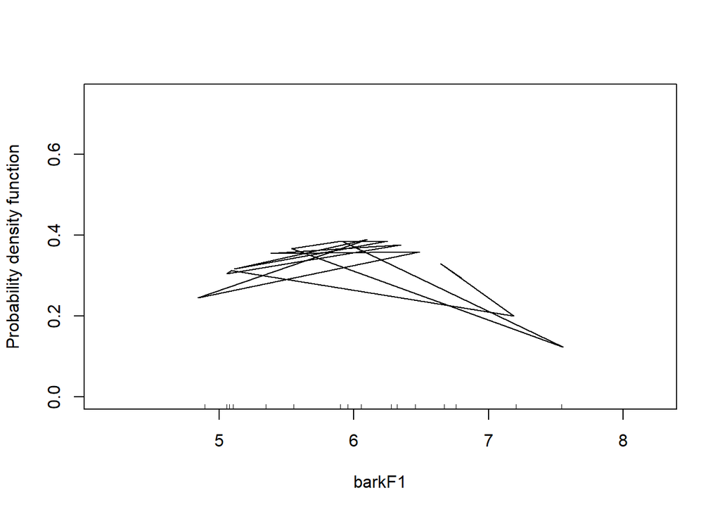

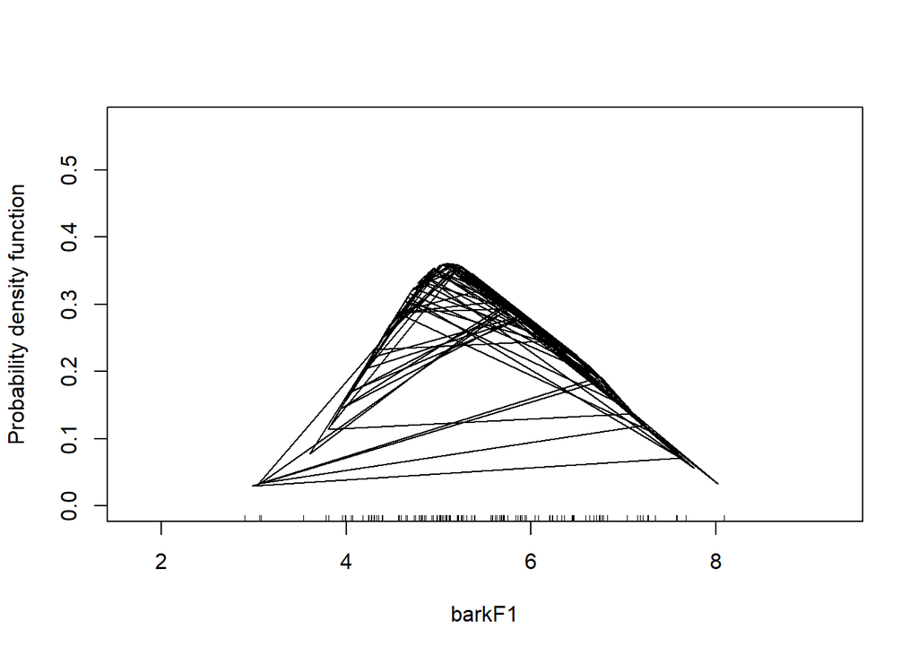

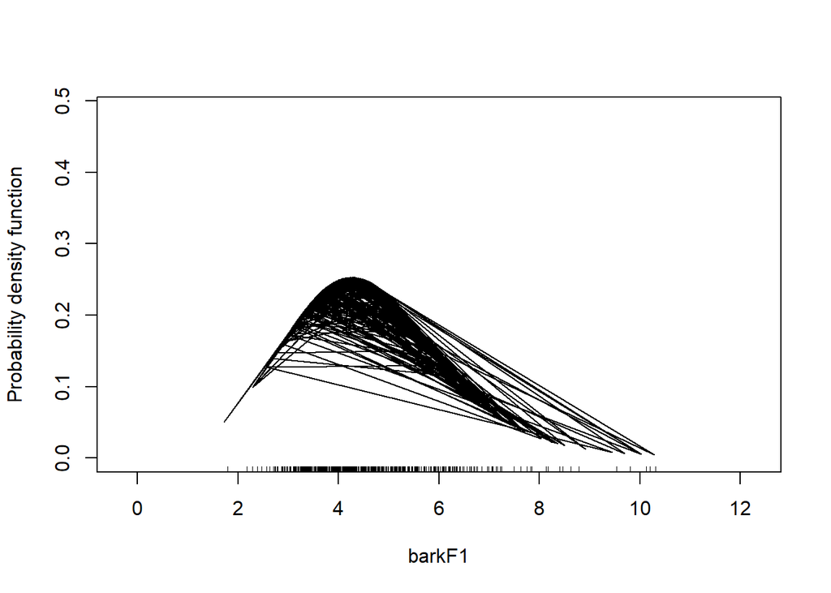

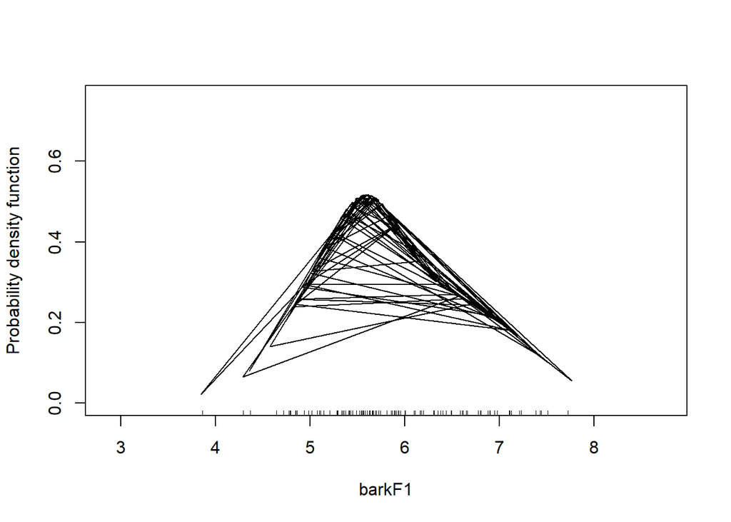

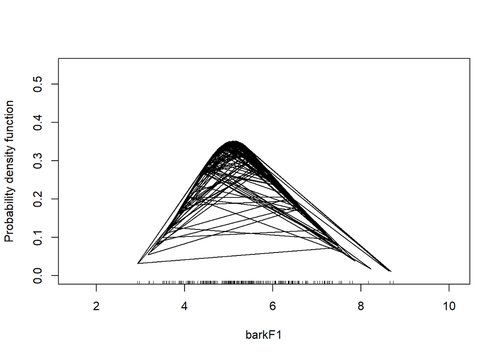

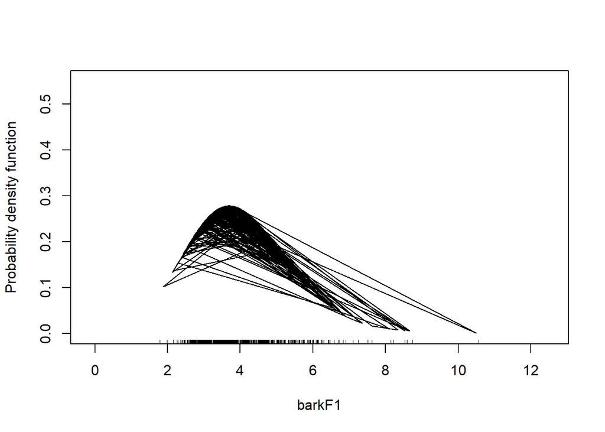

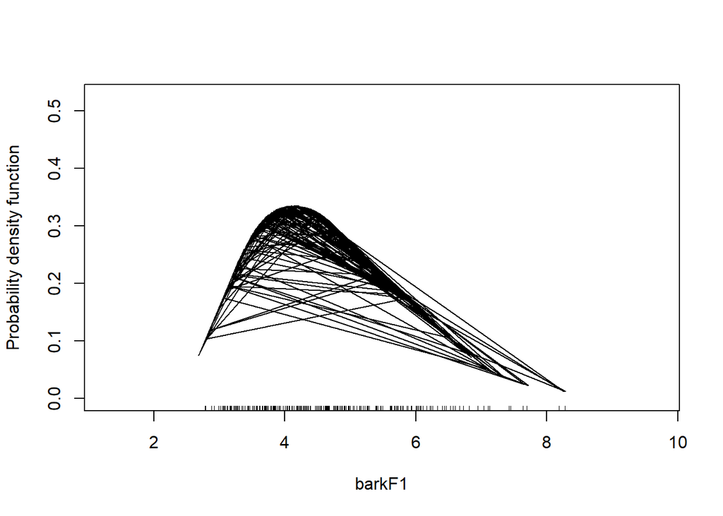

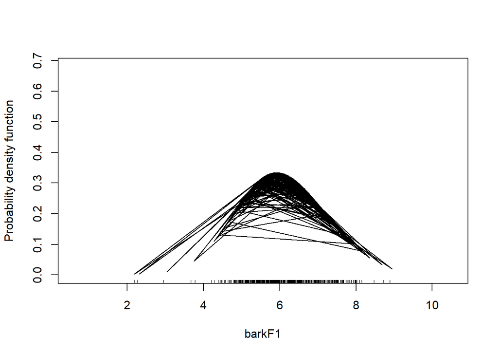

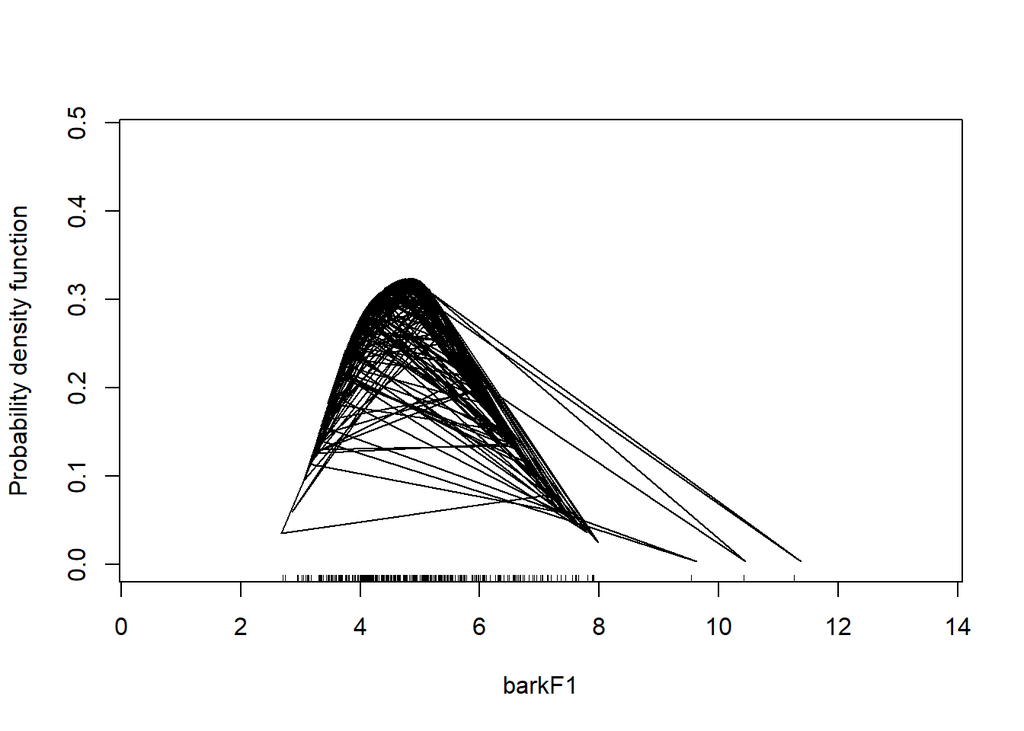

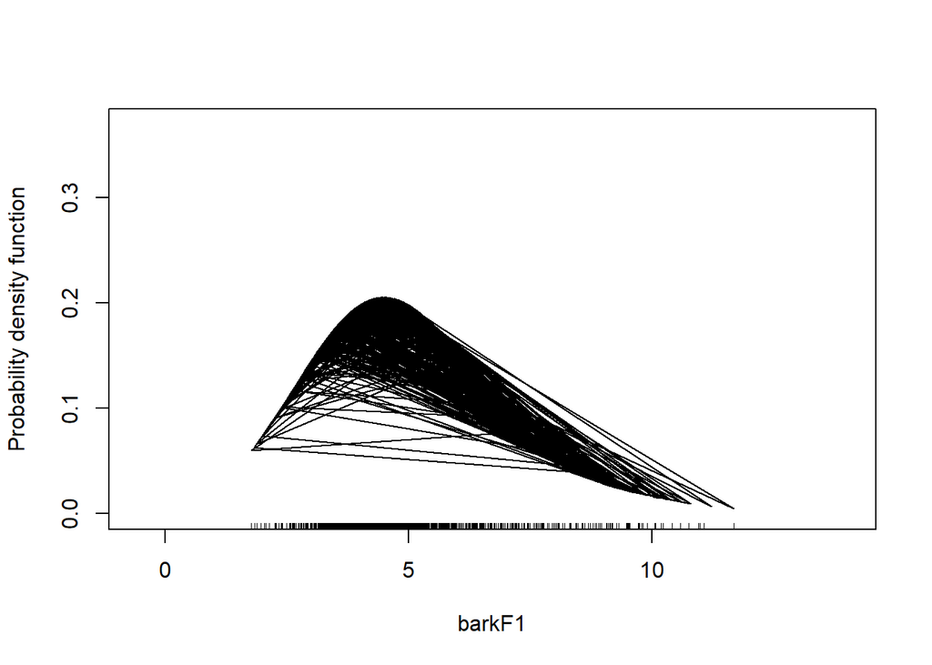

[62 more figures not shown]

```r
# inspect
nrow(fdat); head(fdat); summary(fdat$densF1)
```

```
## [1] 12902
```

```
## # A tibble: 6 × 54
## # Groups:   type, tvariety, label [6]
##   id    Word     F1    F2 Vowel Gender Duration WordClass Frequency
##   <chr> <chr> <dbl> <dbl> <fct> <fct>     <dbl> <fct>         <dbl>
## 1 6     <NA>   698. 1329. <NA>  <NA>         NA <NA>             NA
## 2 7     <NA>   714. 1357. <NA>  <NA>         NA <NA>             NA
## 3 10    <NA>   497. 2031. <NA>  <NA>         NA <NA>             NA
## 4 6     <NA>   581. 1008. <NA>  <NA>         NA <NA>             NA
## 5 7     <NA>   638. 1169. <NA>  <NA>         NA <NA>             NA
## 6 10    <NA>   418. 1328. <NA>  <NA>         NA <NA>             NA
## # ℹ 45 more variables: NonNativeLike <fct>, Speaker <fct>, Proficiency <fct>,
## #   tmin <dbl>, tmax <dbl>, label <chr>, word <chr>, file <chr>,
## #   midpoint <dbl>, F3 <dbl>, vowel <chr>, type <chr>, speaker <chr>,
## #   tgender <chr>, tformants <chr>, tvariety <chr>, Code <chr>, Country <chr>,
## #   gender <chr>, Age <int>, Yrs.of.Stay....Yrs. <chr>, ENS.Type <chr>,
## #   Major..Occupation <chr>, Test <chr>, Score <chr>, Listening <chr>,
## #   Speaking <chr>, Pronunciation <chr>, prof <fct>, target_f1 <dbl>, …
```

```
##          Min.       1st Qu.        Median          Mean       3rd Qu.
## 0.00100369295 0.18551782725 0.22088640450 0.22511956784 0.27229034206
##          Max.
## 0.62230954634
```

```r
fdat <- fdat %>%
  # remove data point within the lowest 25 percent of densities among F1 and F2 values
  # but when label = A: and tvariety is gb
  dplyr::mutate(rmv = ifelse(label == "A:" & tvariety == "gb", "keep", "remove")) %>%
  dplyr::rowwise() %>%
  dplyr::filter(rmv == "keep" | densF1 > qnt1F1 | densF2 > qnt1F2) %>%
  # remove superfluous columns
  dplyr::select(-densF1, -densF2, -qnt1F1, -qnt1F2, -cutoff_duration, -rmv)
# inspect
head(fdat); nrow(fdat)
```

```
## # A tibble: 6 × 49
## # Rowwise:  label, type, tvariety
##   id    Word     F1    F2 Vowel Gender Duration WordClass Frequency
##   <chr> <chr> <dbl> <dbl> <fct> <fct>     <dbl> <fct>         <dbl>
## 1 6     <NA>   698. 1329. <NA>  <NA>         NA <NA>             NA
## 2 7     <NA>   714. 1357. <NA>  <NA>         NA <NA>             NA
## 3 6     <NA>   581. 1008. <NA>  <NA>         NA <NA>             NA
## 4 7     <NA>   638. 1169. <NA>  <NA>         NA <NA>             NA
## 5 10    <NA>   418. 1328. <NA>  <NA>         NA <NA>             NA
## 6 7     <NA>   479.  996. <NA>  <NA>         NA <NA>             NA
## # ℹ 40 more variables: NonNativeLike <fct>, Speaker <fct>, Proficiency <fct>,
## #   tmin <dbl>, tmax <dbl>, label <chr>, word <chr>, file <chr>,
## #   midpoint <dbl>, F3 <dbl>, vowel <chr>, type <chr>, speaker <chr>,
## #   tgender <chr>, tformants <chr>, tvariety <chr>, Code <chr>, Country <chr>,
## #   gender <chr>, Age <int>, Yrs.of.Stay....Yrs. <chr>, ENS.Type <chr>,
## #   Major..Occupation <chr>, Test <chr>, Score <chr>, Listening <chr>,
## #   Speaking <chr>, Pronunciation <chr>, prof <fct>, target_f1 <dbl>, …
```

```
## [1] 9695
```

# Remove GB target

```r
fdat <- fdat %>%
  dplyr::filter(tvariety != "gb")
```

# Normalization

See [here](https://marissabarlaz.github.io/portfolio/vowelnormalization/)

Gender normalization

```r
# Using mean F3 of open vowels (vowels with F1>600) to approximate female F1&F2 to those of male
tempvowel <- fdat %>%
  dplyr::filter(F1 > 600) %>%
  dplyr::group_by(gender) %>%
  dplyr::mutate(meanF3 = mean(F3))
# extract k: k = ratio of Female F3 to Male F3
k <- max(tempvowel$meanF3) / min(tempvowel$meanF3)
# perform normalization
fdat <- fdat %>%
  dplyr::mutate(barkF1 = phonR::normBark(F1),
                barkF2 = phonR::normBark(F2)) %>%
  dplyr::mutate(normF1 = dplyr::if_else(gender == "f", F1*k, F1),
                normF2 = dplyr::if_else(gender == "f", F2*k, F2))
```

calculate distance from target vowel centroid for each token

```r
tcentroid <- fdat %>%
  dplyr::filter(type == "ENS") %>%
  dplyr::group_by(tvariety, vowel) %>%
  dplyr::summarise(cF1 = median(barkF1),
                   cF2 = median(barkF2))
# inspect
head(tcentroid)
```

```
## # A tibble: 6 × 4
## # Groups:   tvariety [1]
##   tvariety vowel   cF1   cF2
##   <chr>    <chr> <dbl> <dbl>
## 1 us       iː     4.09  12.8
## 2 us       uː     4.07  10.7
## 3 us       æ      5.96  10.7
## 4 us       ɒ      6.08  10.6
## 5 us       ɔː     6.84  10.1
## 6 us       ɛ      5.05  11.1
```

combine

```r
fdat <- dplyr::left_join(fdat, tcentroid) %>%
  # euclidean distance
  dplyr::rowwise() %>%
  dplyr::mutate(ED = sqrt((barkF1-cF1)^2 + (barkF2-cF2)^2)) %>%
  # remove superfluous columns
  dplyr::select(-remove)
# inspect
head(fdat)
```

```
## # A tibble: 6 × 53
## # Rowwise:
##   id    Word     F1    F2 Vowel Gender Duration WordClass Frequency
##   <chr> <chr> <dbl> <dbl> <fct> <fct>     <dbl> <fct>         <dbl>
## 1 7     <NA>   714. 1357. <NA>  <NA>         NA <NA>             NA
## 2 7     <NA>   638. 1169. <NA>  <NA>         NA <NA>             NA
## 3 7     <NA>   479.  996. <NA>  <NA>         NA <NA>             NA
## 4 11    <NA>   508. 1238. <NA>  <NA>         NA <NA>             NA
## 5 27    <NA>   593. 1791. <NA>  <NA>         NA <NA>             NA
## 6 47    <NA>   860. 1553. <NA>  <NA>         NA <NA>             NA
## # ℹ 44 more variables: NonNativeLike <fct>, Speaker <fct>, Proficiency <fct>,
## #   tmin <dbl>, tmax <dbl>, label <chr>, word <chr>, file <chr>,
## #   midpoint <dbl>, F3 <dbl>, vowel <chr>, type <chr>, speaker <chr>,
## #   tgender <chr>, tformants <chr>, tvariety <chr>, Code <chr>, Country <chr>,
## #   gender <chr>, Age <int>, Yrs.of.Stay....Yrs. <chr>, ENS.Type <chr>,
## #   Major..Occupation <chr>, Test <chr>, Score <chr>, Listening <chr>,
## #   Speaking <chr>, Pronunciation <chr>, prof <fct>, target_f1 <dbl>, …
```

# Gramm. Status of Word

```r
gram <- c("be", "but", "did", "do", "get", "gets", "got", "had", "has", "he", "his",
          "she", "that", "this", "too", "was", "we", "what", "who", "with")
fdat <- fdat %>%
  # gramm. category of word
  dplyr::mutate(WordType = ifelse(word %in% gram, "grammatical", "lexical"))
```

remove superfluous variables

```r
fdat <- fdat %>%
  dplyr::select(id, label, word, file, F1, F2, speaker, vowel,
                label, type, gender, Age, tvariety, edist, barkF1,
                barkF2, fspeaker, lobF1, lobF2, duration, normF1,
                normF2, cF1, cF2, ED, WordType, prof) %>%
  # create new speaker column
  dplyr::mutate(speaker = paste0(type, speaker))
# inspect
head(fdat)
```

```
## # A tibble: 6 × 26
## # Rowwise:
##   id    label word  file      F1    F2 speaker vowel type  gender   Age tvariety
##   <chr> <chr> <chr> <chr>  <dbl> <dbl> <chr>   <chr> <chr> <chr>  <int> <chr>
## 1 7     {     that  SM_CH…  714. 1357. CHN001  æ     CHN   m         20 us
## 2 7     Q     was   SM_CH…  638. 1169. CHN001  ɒ     CHN   m         20 us
## 3 7     I     with  SM_CH…  479.  996. CHN001  ɪ     CHN   m         20 us
## 4 11    u:    do    SM_CH…  508. 1238. CHN001  uː    CHN   m         20 us
## 5 27    I     with  SM_CH…  593. 1791. CHN002  ɪ     CHN   m         20 us
## 6 47    I     this  SM_CH…  860. 1553. CHN003  ɪ     CHN   m         19 us
## # ℹ 14 more variables: edist <dbl>, barkF1 <dbl>, barkF2 <dbl>, fspeaker <chr>,
## #   lobF1 <dbl[,1]>, lobF2 <dbl[,1]>, duration <dbl>, normF1 <dbl>,
## #   normF2 <dbl>, cF1 <dbl>, cF2 <dbl>, ED <dbl>, WordType <chr>, prof <fct>
```

## Save data

```r
# save
base::saveRDS(fdat, file = here::here("data", "cleandat.rda"))
```

# Citation & Session Info

Schweinberger, Martin. 2023. A Corpus-Based Acoustic Analysis of Monophthong Vowels among Chinese Learners and Native Speakers of English. Brisbane: The University of Queensland, School of Languages and Cultures.